# Project_1_Olympic

required libraries: library (dplyr) library (tidyr)

Unzipping of files was done manually.

## Task 1

```r
all_files <- list.files (path = "../data/", pattern = "*.csv", full.names = TRUE)
all_files
```

```
##  [1] "../data/athlete_events00.csv" "../data/athlete_events01.csv"
##  [3] "../data/athlete_events02.csv" "../data/athlete_events03.csv"
##  [5] "../data/athlete_events04.csv" "../data/athlete_events05.csv"
##  [7] "../data/athlete_events06.csv" "../data/athlete_events07.csv"
##  [9] "../data/athlete_events08.csv" "../data/athlete_events09.csv"
## [11] "../data/athlete_events10.csv" "../data/athlete_events11.csv"
```

```r
df = lapply(all_files, function(i){
  x  = read.csv(i)
  x
})
df = do.call("rbind.data.frame", df)
```

The result is a dataset of 271115 observations of 15 variables.

## Task 2

```r
summary (df)
```

```
##        ID             Name               Sex                 Age
##  Min.   :     1   Length:271115      Length:271115      Min.   : 10.00
##  1st Qu.: 34643   Class :character   Class :character   1st Qu.: 21.00
##  Median : 68205   Mode  :character   Mode  :character   Median : 24.00
##  Mean   : 68249                                         Mean   : 25.56
##  3rd Qu.:102097                                         3rd Qu.: 28.00
##  Max.   :135571                                         Max.   :240.00
##                                                         NA's   :9476
##      Height          Weight          Team               NOC
##  Min.   :127.0   Min.   :  7.0   Length:271115      Length:271115
##  1st Qu.:168.0   1st Qu.: 60.0   Class :character   Class :character
##  Median :175.0   Median : 70.0   Mode  :character   Mode  :character
##  Mean   :175.3   Mean   : 70.7
##  3rd Qu.:183.0   3rd Qu.: 79.0
##  Max.   :340.0   Max.   :214.0
##  NA's   :60172   NA's   :62876
##     Games                Year         Season              City
##  Length:271115      Min.   :1896   Length:271115      Length:271115
##  Class :character   1st Qu.:1960   Class :character   Class :character
##  Mode  :character   Median :1988   Mode  :character   Mode  :character
##                     Mean   :1978
##                     3rd Qu.:2002
##                     Max.   :2016
##                     NA's   :7
##     Sport              Event              Medal
##  Length:271115      Length:271115      Length:271115
##  Class :character   Class :character   Class :character
##  Mode  :character   Mode  :character   Mode  :character
##
##
##
##
```

```r
sum(is.na(df))
```

```
## [1] 363855
```

```r
df %>% filter (Age > 80)
```

```
##       ID                       Name Sex Age Height Weight          Team NOC
## 1   5146      George Denholm Armour   M  84     NA     NA Great Britain GBR
## 2  23459 Flicien Jules mile Courbet   M 240     NA     NA       Belgium BEL
## 3  31173 Thomas Cowperthwait Eakins   M  88     NA     NA United States USA
## 4  31173 Thomas Cowperthwait Eakins   M  88     NA     NA United States USA
## 5  31173 Thomas Cowperthwait Eakins   M  88     NA     NA United States USA
## 6  49663              Winslow Homer   M  96     NA     NA United States USA
## 7  77710       Robert Tait McKenzie   M  81     NA     NA        Canada CAN
## 8 118789               Louis Tauzin   M  81     NA     NA        France FRA
## 9 128719     John Quincy Adams Ward   M  97     NA     NA United States USA
##         Games Year Season        City            Sport
## 1 1948 Summer 1948 Summer      London Art Competitions
## 2 1912 Summer 1912 Summer   Stockholm         Swimming
## 3 1932 Summer 1932 Summer Los Angeles Art Competitions
## 4 1932 Summer 1932 Summer Los Angeles Art Competitions
## 5 1932 Summer 1932 Summer Los Angeles Art Competitions
## 6 1932 Summer 1932 Summer Los Angeles Art Competitions
## 7 1948 Summer 1948 Summer      London Art Competitions
## 8 1924 Summer 1924 Summer       Paris Art Competitions
## 9 1928 Summer 1928 Summer   Amsterdam Art Competitions
##                                               Event Medal
## 1    Art Competitions Mixed Painting, Unknown Event  <NA>
## 2            Swimming Men's 200 metres Breaststroke  <NA>
## 3    Art Competitions Mixed Painting, Unknown Event  <NA>
## 4    Art Competitions Mixed Painting, Unknown Event  <NA>
## 5    Art Competitions Mixed Painting, Unknown Event  <NA>
## 6    Art Competitions Mixed Painting, Unknown Event  <NA>
## 7 Art Competitions Mixed Sculpturing, Unknown Event  <NA>
## 8                Art Competitions Mixed Sculpturing  <NA>
## 9       Art Competitions Mixed Sculpturing, Statues  <NA>
```

```r
unique (df$Age)
```

```
##  [1]  24  23  34  21  25  27  31  33  18  26  22  30  32  28  54  20  17  43  47
## [20]  29  41  45  49  53  57  NA  19  38  35  16  37  15  42  46  40  36  14  39
## [39]  48  52  44  55  50  71  63  51  58  13  60  75  65  56  64  68  84  12  72
## [58]  59  61  70  74  62  67  69  73  66  11 240  76  88  96  80  10  81  77  97
```

There are 9 entries in which athlete’s age is over 80. For now, I have decided to drop the most obvious mistake - 240 year. The others participated in art competitions, and I checked the participant of 84 years - he really was that age.

```r
df$Age[df$Age==240] <- NA
```

The same was done with height - 340 was excluded.

```r
df$Height[df$Height==340] <- NA
```

```r
df$Sex[df$Sex=="G"] <- NA
```

Weight of 7 was excluded as well. The next minimum was around 25, but it was a weight of a 14-year old female gymnast, so it would make sense.

```r
df$Weight[df$Weight=="7"] <- NA
```

There were some typos in Games’ names, so they were just corrected.

```r
df$Games[df$Games=="2004 Summe"] <- "2004 Summer"
df$Games[df$Games=="2000 Su"] <- "2000 Summer"
df$Games[df$Games==""] <- NA
df$Medal[df$Medal==""] <- NA
```

In general, the method of looking for invalid values was using the “unique” command or looking at summaries. Then obvious typos or non-sense values were excluded. Still, it would be possible to miss some of the mistakes in columns such as “Team” which include a lot of unique values.

## Task 3

Age of the youngest male and female athletes at 1992 Olympics:

```r
df %>% filter (Games == "1992 Summer") %>% group_by(Sex) %>% slice(which.min(Age))
```

```
## # A tibble: 2 x 15
## # Groups:   Sex [2]
##      ID Name     Sex     Age Height Weight Team   NOC   Games  Year Season City
##   <int> <chr>    <chr> <int>  <int>  <dbl> <chr>  <chr> <chr> <int> <chr>  <chr>
## 1 60854 Judit K~ F        12    171     57 Hunga~ HUN   1992~  1992 Summer Barc~
## 2 37333 Carlos ~ M        11     NA     NA Spain  ESP   1992~  1992 Summer Barc~
## # ... with 3 more variables: Sport <chr>, Event <chr>, Medal <chr>
```

So it is 12 for a girl and 11 for a boy.

## Task 4

Mean and sd for the Height variable for male and female athletes:

```r
df %>% group_by(Sex) %>% summarise(mean = mean(Height, na.rm = T), sd = sd(Height, na.rm = T))
```

```
## # A tibble: 4 x 3
##   Sex    mean    sd
##   <chr> <dbl> <dbl>
## 1 ""     NaN  NA
## 2 "F"    168.  8.78
## 3 "M"    179.  9.36
## 4  <NA>  182  NA
```

## Task 5

Height for tennis female athletes at 2000 Olympics:

```r
df %>% filter (Sex == "F") %>% filter (Games == "2000 Summer") %>% filter (Sport == "Tennis") %>% summarise(mean = round(mean(Height, na.rm = T), 1), sd = round(sd(Height, na.rm = T), 1))
```

```
##    mean  sd
## 1 171.8 6.5
```

## Task 6

The heaviest athlete at 2006 Olympics:

```r
df %>% filter (Games == "2006 Winter") %>% slice(which.max(Weight)) %>% select (Sport)
```

```
##      Sport
## 1 Skeleton
```

He participated in Skeleton.

## Task 7

Women gold medals from 1980 to 2010

```r
df %>% filter (Year >= 1980 & Year <= 2010) %>% filter (Sex == "F") %>% summarise(
  count = n(),
  gold_count = sum(Medal == "Gold", na.rm = T)
)
```

```
##   count gold_count
## 1 44044       2249
```

2249 gold medals.

## Task 8

John Aalberg participated in Games:

```r
df %>% filter (Name == "John Aalberg") %>% group_by(Year) %>%
  summarise(n = n())
```

```
## # A tibble: 2 x 2
##    Year     n
##   <int> <int>
## 1  1992     4
## 2  1994     4
```

4 events in 1992 and also 4 in 1994.

## Task 9

One athlete could participate in several events, so one athlete was only counted one time:

```r
df %>% filter (Games == "2008 Summer") %>% filter (Age >= 15 & Age < 25) %>% count(Name) %>% summarise(n = n())
```

```
##      n
## 1 4783
```

For age group 15-25 there were 4783 athletes

```r
df %>% filter (Games == "2008 Summer") %>% filter (Age >= 25 & Age < 35) %>% count(Name) %>% summarise(n = n())
```

```
##      n
## 1 5376
```

For age group 25-35 there were 5376 athletes

```r
df %>% filter (Games == "2008 Summer") %>% filter (Age >= 35 & Age < 45) %>% count(Name) %>% summarise(n = n())
```

```
##     n
## 1 630
```

For age group 35-45: 630 athletes

```r
df %>% filter (Games == "2008 Summer") %>% filter (Age >= 45 & Age < 55) %>% count(Name) %>% summarise(n = n())
```

```
##    n
## 1 76
```

For age group 45-55: 76 athletes.

So the highest number of athletes (5376) is within 25-35 age range, the lowest (76) is for 45-55 age range.

## Task 10

Various sports at 2002 and 1994 Olympics:

```r
df %>% filter (Games == "2002 Winter") %>% count(Sport) %>% summarise(n = n())
```

```
##    n
## 1 15
```

```r
df %>% filter (Games == "1994 Winter") %>% count(Sport) %>% summarise(n = n())
```

```
##    n
## 1 12
```

15 sports at 2002 Olympics and 12 at 1994 Olympics.

## Task 11

```r
df %>% filter (Season == "Winter") %>% filter(!is.na(Medal))%>% group_by(Medal, NOC) %>%
  summarise(n = n()) %>% arrange(desc(n)) %>% group_by(Medal) %>% slice (1)
```

```
## # A tibble: 3 x 3
## # Groups:   Medal [3]
##   Medal  NOC       n
##   <chr>  <chr> <int>
## 1 Bronze FIN     215
## 2 Gold   CAN     305
## 3 Silver USA     308
```

During winter Olympics, Finland has the most bronze medals, USA - most silver, Canada - most gold.

```r
df %>% filter (Season == "Summer") %>% filter(!is.na(Medal))%>% group_by(Medal, NOC) %>%
  summarise(n = n()) %>% arrange(desc(n)) %>% group_by(Medal) %>% slice (1)
```

```
## # A tibble: 3 x 3
## # Groups:   Medal [3]
##   Medal  NOC       n
##   <chr>  <chr> <int>
## 1 Bronze USA    1197
## 2 Gold   USA    2472
## 3 Silver USA    1333
```

During the summer Olympics, USA has the highest number of medals in each category

## Task 12

Z scores of height:

```r
df$Height_z_scores <- scale (df$Height)
```

## Task 13

Additional task

## Task 14

Compare height, weight and age of men of women. T test was used. There was no need to check the normality as the number of observations was huge. Also, Shapiro Wilk test has a limitation of 5000 observations as its upper border.

```r
df_women_winter <- df %>% filter (Season == "Winter") %>% filter (Sex == "F")
df_men_winter <- df %>% filter (Season == "Winter") %>% filter (Sex == "M")
t.test(df_women_winter$Height, df_men_winter$Height)
```

```
##
##  Welch Two Sample t-test
##
## data:  df_women_winter$Height and df_men_winter$Height
## t = -184.8, df = 29342, p-value < 2.2e-16
## alternative hypothesis: true difference in means is not equal to 0
## 95 percent confidence interval:
##  -12.26962 -12.01208
## sample estimates:
## mean of x mean of y
##  166.5283  178.6691
```

t = -184.8, df = 29342, p-value < 2.2e-16

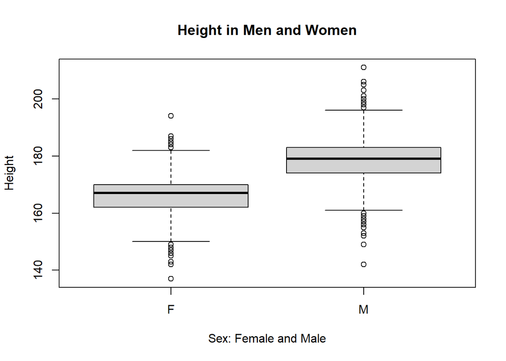

```r
df_winter <- df %>% filter (Season == "Winter")
boxplot(df_winter$Height ~ df_winter$Sex, main="Height in Men and Women", xlab="Sex: Female and Male", ylab="Height" )
```

The differences can be observed on boxplot.

```r
t.test(df_women_winter$Weight, df_men_winter$Weight)
```

```
##
##  Welch Two Sample t-test
##
## data:  df_women_winter$Weight and df_men_winter$Weight
## t = -187.85, df = 36296, p-value < 2.2e-16
## alternative hypothesis: true difference in means is not equal to 0
## 95 percent confidence interval:
##  -16.77517 -16.42871
## sample estimates:
## mean of x mean of y
##  59.75555  76.35749
```

t = -187.85, df = 36296, p-value < 2.2e-16

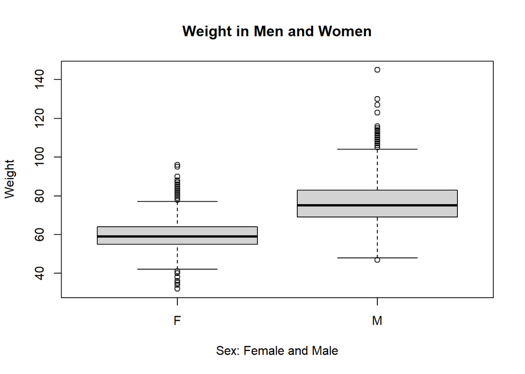

```r
boxplot(df_winter$Weight ~ df_winter$Sex, main="Weight in Men and Women", xlab="Sex: Female and Male", ylab="Weight" )
```

```r
t.test(df_women_winter$Age, df_men_winter$Age)
```

```
##
##  Welch Two Sample t-test
##
## data:  df_women_winter$Age and df_men_winter$Age
## t = -32.239, df = 29455, p-value < 2.2e-16
## alternative hypothesis: true difference in means is not equal to 0
## 95 percent confidence interval:
##  -1.580799 -1.399600
## sample estimates:
## mean of x mean of y
##   24.0142   25.5044
```

t = -32.239, df = 29455, p-value < 2.2e-16

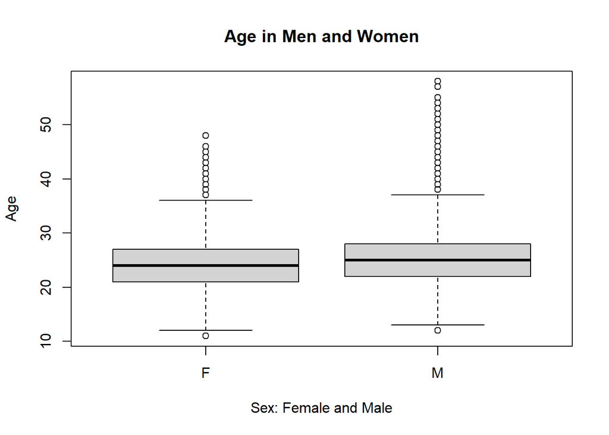

```r
boxplot(df_winter$Age ~ df_winter$Sex, main="Age in Men and Women", xlab="Sex: Female and Male", ylab="Age" )
```

## Task 15

Team and Medal - can they be related?

```r
df_no_na <- df %>% filter(!is.na(Medal)) %>% filter(!is.na(Team))
chisq.test(table(df_no_na$Team, df_no_na$Medal))
```

```
##
##  Pearson's Chi-squared test
##
## data:  table(df_no_na$Team, df_no_na$Medal)
## X-squared = 5293.4, df = 994, p-value < 2.2e-16
```

## Conclusion

In this project data on Olympic athletes was analyzed. After initial data extraction and pre-processing, exploratory data analysis was done. Statistical methods - such as t-test, chi-squared - were used to compare differences between samples.